# Big-sur data analysis

## Table of Contents:

- Univariate statistics of fire and disease impacts
- Underlying drivers of biomass and stem density changes
- Tracking stems through time

## Objectives: quantifying fire/disease impacts

- Quantify biomass, stem density changes pre to post fire. Compare across burn scar, species, and status.
  - Used mixed effects models to understand underlying relationships.
- Track stems through time to quantify rates of mortality, snag fall and CWD decomposition.
  - Use survival analysis (mortality), ?? (snag fall), regression (CWD decomp.)

### Needed libraries

```r
library(tidyverse)
library(broom)
library(gtsummary)
library(survival)
library(ggsurvfit)
library(lme4)
library(lmerTest)
library(here)
library(knitr)
library(patchwork)
library(gt)
```

### Recycled functions

```r
read_me <- function(path){
  read_csv(here("data", path))
}
export_image <- function(img, path){
  ggsave(filename = here("exports", path), plot=img, width=12, height=8)
}

climate_theme <- function(color = "slategray1") {
  theme(
  plot.title = element_text(
      size = 16,
      family = "Times New Roman",
      color = "black",
      margin = margin(b = 15)
    ),
    # add border 1)
    panel.border = element_rect(colour = "black", fill = NA, linetype = 1),
    # color background 2)
    panel.background = element_rect(fill = color),
    # modify grid 3)
    panel.grid.major.x = element_blank(),
    panel.grid.minor.x = element_blank(),
    panel.grid.major.y =  element_blank(),
    panel.grid.minor.y = element_blank(),
    # modify text, axis and colour 4) and 5)
    axis.text = element_text(colour = "black",  family = "Times New Roman"),
    axis.title = element_text(colour = "black", family = "Times New Roman"),
    axis.ticks = element_line(colour = "black"),
    legend.position = "right"
  )
}
# darkolivegreen3
```

## Univariate statistics of fire and disease impacts

### Living Biomass changes

```r
biomass_changes <- read_me("./clean/post_fire_summary.csv")
burn_change <- function(burn, time1) {
  df <- biomass_changes |>
    filter(BurnScar == burn) |>
    select(!c(Elevation,Slope,Fire)) |>
    mutate(Pre = case_when(
      SampleYear <= time1 ~ "Pre",
      SampleYear >=  time1 ~ "Post",
      TRUE ~ "NA"))
  df_mod1 <- df |>
    filter(Pre %in% c("Pre","Post")) |>
    group_by(Plot, Species, BurnScar, PRam, Pre) |>
    summarise(
      TotalStem   = sum(TotalStem, na.rm = TRUE),
      LiveBiomass = sum(LiveBiomass, na.rm = TRUE),
      .groups = "drop"
    ) |>
    pivot_wider(names_from="Pre", values_from=c("TotalStem","LiveBiomass"))
  # only want to evaluate data with both pre and post
  df_mod2 <- na.omit(df_mod1)
  df_mod3 <- df_mod2 |>
    mutate(ChangeStem = TotalStem_Post - TotalStem_Pre,
      ChangeBiomass = LiveBiomass_Post - LiveBiomass_Pre) |>
    select(c(1,2,3,4,9,10))
  return(df_mod3)
}
# apply summary function to dataset we want
sites_tree <- tibble(
  burn  = c("dolan", "sober", "chalk", "control", "dolan_chalk", "sober_chalk"),
  time1 = c(2020, 2016, 2007, 2016, 2007, 2007)
)
demo_tree <- pmap_df(sites_tree, burn_change)

post_fire_summary_biomass <- demo_tree |>
  group_by(Species, BurnScar, PRam) |>
  summarize( n = n(),
            MeanStemChange = mean(ChangeStem, na.rm=TRUE),
            MeanBiomassChange = mean(ChangeBiomass, na.rm=TRUE),
            MedianStemChange    = median(ChangeStem, na.rm = TRUE),
            MedianBiomassChange = median(ChangeBiomass, na.rm = TRUE),
            SdStemChange = sd(ChangeStem, na.rm=TRUE),
            SdBiomassChange = sd(ChangeBiomass, na.rm=TRUE)
) |>
  rename(
         `Mean Change in Stem Density` = 3,
     `Mean Change in Biomass` = 4,
     `Median Change in Stem Density` = 5,
     `Median Change in Biomass` = 6,
  `SD Change in Stem Density` = 7,
  `SD Change in Biomass` = 8)


kable(post_fire_summary_biomass)
```

| Species | BurnScar | Mean Change in Stem Density | Mean Change in Biomass | Median Change in Stem Density | Median Change in Biomass | SD Change in Stem Density | SD Change in Biomass | SdStemChange | SdBiomassChange |
| --- | --- | --- | --- | --- | --- | --- | --- | --- | --- |
| ARME | chalk | 1 | 4 | 64.250000 | -4735.6891 | 31.0 | -2.475208e+04 | 92.211261 | 95314.143 |
| ARME | control | 1 | 1 | 0.000000 | -4706.5006 | 0.0 | -4.706501e+03 | NA | NA |
| ARME | dolan | 0 | 3 | -25.333333 | 2931.9403 | -24.0 | -1.358863e+02 | 25.026653 | 12853.139 |
| ARME | dolan | 1 | 2 | -58.500000 | -27506.5312 | -58.5 | -2.750653e+04 | 6.363961 | 34618.900 |
| ARME | dolan_chalk | 0 | 2 | -9.000000 | -51232.8484 | -9.0 | -5.123285e+04 | 11.313709 | 68145.505 |
| ARME | sober | 0 | 1 | 6.000000 | 90987.8879 | 6.0 | 9.098789e+04 | NA | NA |
| ARME | sober | 1 | 7 | 9.857143 | -40081.6650 | 9.0 | -4.193882e+04 | 8.355209 | 176753.024 |
| ARME | sober_chalk | 0 | 13 | 45.384615 | -30509.1849 | 13.0 | -6.785663e+03 | 88.262429 | 57134.049 |
| ARME | sober_chalk | 1 | 5 | 40.200000 | 126975.2275 | 61.0 | 2.625905e+03 | 37.943379 | 265297.811 |
| LIDE | chalk | 1 | 8 | 146.250000 | -58083.0346 | 100.0 | -9.858739e+03 | 160.361868 | 109802.840 |
| LIDE | control | 1 | 8 | -15.625000 | -106051.4322 | -0.5 | 1.018131e+02 | 29.310834 | 225043.485 |
| LIDE | dolan | 0 | 1 | -491.000000 | -55587.7454 | -491.0 | -5.558775e+04 | NA | NA |
| LIDE | dolan_chalk | 0 | 10 | 10.200000 | 14074.8575 | -9.0 | -1.183408e+02 | 88.882944 | 188749.720 |
| LIDE | dolan_chalk | 1 | 5 | -6.600000 | -7345.3124 | 3.0 | -4.498775e+04 | 86.984481 | 170903.905 |
| LIDE | sober | 0 | 1 | -45.000000 | 222393.2176 | -45.0 | 2.223932e+05 | NA | NA |
| LIDE | sober | 1 | 23 | -27.086956 | -150404.8317 | -25.0 | -2.304594e+04 | 77.100827 | 335708.111 |
| LIDE | sober_chalk | 0 | 10 | 146.600000 | 289236.8865 | 6.0 | 1.772587e+05 | 367.269867 | 336650.570 |
| LIDE | sober_chalk | 1 | 17 | 55.294118 | 20792.4553 | 10.0 | -2.266228e+03 | 134.980908 | 212413.670 |
| PIPO | dolan | 0 | 1 | 1.000000 | 62751.3028 | 1.0 | 6.275130e+04 | NA | NA |
| PIPO | dolan_chalk | 0 | 2 | -0.500000 | -7988.8256 | -0.5 | -7.988826e+03 | 2.121320 | 17540.097 |
| PSME | dolan_chalk | 0 | 1 | 0.000000 | 13612.6089 | 0.0 | 1.361261e+04 | NA | NA |
| PSME | sober_chalk | 0 | 2 | 2.500000 | 316585.6055 | 2.5 | 3.165856e+05 | 2.121320 | 265102.306 |
| PSME | sober_chalk | 1 | 1 | -14.000000 | 3572.0807 | -14.0 | 3.572081e+03 | NA | NA |
| QUAG | chalk | 1 | 4 | 40.250000 | 416239.9653 | 27.5 | 3.969031e+05 | 42.279822 | 460112.432 |
| QUAG | control | 0 | 1 | -2.000000 | -54147.5406 | -2.0 | -5.414754e+04 | NA | NA |
| QUAG | control | 1 | 4 | -8.750000 | -263712.0880 | -10.5 | -1.476638e+05 | 6.701990 | 334921.250 |
| QUAG | dolan | 0 | 4 | -1.500000 | -16041.8932 | -1.0 | -1.480000e+04 | 1.914854 | 25112.150 |
| QUAG | dolan | 1 | 6 | -15.333333 | -525585.9305 | -15.5 | -5.281188e+05 | 8.640988 | 367868.553 |
| QUAG | dolan_chalk | 0 | 5 | 12.000000 | 285369.4926 | 4.0 | 6.338939e+04 | 17.677670 | 470390.524 |
| QUAG | dolan_chalk | 1 | 1 | 93.000000 | 957347.7313 | 93.0 | 9.573477e+05 | NA | NA |
| QUAG | sober | 1 | 3 | -2.666667 | -42502.4767 | -2.0 | -4.243287e+04 | 2.081666 | 24618.375 |
| QUAG | sober_chalk | 0 | 5 | 5.200000 | 166882.2258 | 1.0 | -3.620684e-01 | 16.513631 | 374822.998 |
| QUAG | sober_chalk | 1 | 6 | 10.333333 | 192888.9558 | 4.0 | 4.297574e+04 | 21.924111 | 497971.455 |
| SESE | chalk | 1 | 6 | 86.333333 | 651901.7457 | 60.5 | 1.166211e+05 | 68.289580 | 1162602.563 |
| SESE | control | 1 | 7 | -6.000000 | -620806.6909 | -4.0 | 1.151147e+04 | 36.701499 | 1458116.896 |
| SESE | dolan | 0 | 4 | -198.250000 | -1553061.8681 | -137.5 | -8.163049e+05 | 285.928167 | 2173412.246 |
| SESE | dolan | 1 | 7 | -147.857143 | -340206.7505 | -52.0 | -2.253798e+04 | 188.694134 | 1010944.136 |
| SESE | dolan_chalk | 0 | 12 | 8.083333 | 217139.9624 | -9.5 | 1.618207e+04 | 46.947666 | 438548.455 |
| SESE | dolan_chalk | 1 | 7 | 27.142857 | 134849.0076 | 7.0 | 1.972146e+05 | 79.186338 | 311658.223 |
| SESE | sober | 1 | 14 | 34.428571 | -239774.3632 | 33.0 | -1.041434e+04 | 45.705940 | 833842.398 |
| SESE | sober_chalk | 0 | 9 | 132.444444 | 1387715.9646 | 52.0 | 1.336848e+06 | 227.080994 | 1431761.979 |
| SESE | sober_chalk | 1 | 10 | 6.400000 | 127542.5142 | 4.5 | 1.035971e+05 | 66.079414 | 618960.074 |
| UMCA | chalk | 1 | 10 | 131.700000 | -425.3252 | 39.0 | -1.907246e+04 | 238.301886 | 150132.591 |
| UMCA | control | 0 | 1 | -99.000000 | -271080.0521 | -99.0 | -2.710801e+05 | NA | NA |
| UMCA | control | 1 | 8 | -16.500000 | -5963.2595 | -15.0 | 1.592105e+03 | 13.201731 | 27846.195 |
| UMCA | dolan | 0 | 6 | -22.000000 | -11305.2623 | -20.5 | -6.076462e+03 | 19.193749 | 16929.464 |
| UMCA | dolan | 1 | 8 | -125.750000 | -82444.9073 | -69.5 | -1.916584e+04 | 148.602778 | 132923.190 |
| UMCA | dolan_chalk | 0 | 8 | 16.000000 | 521.7103 | 1.0 | -8.991931e+02 | 36.909155 | 41603.312 |
| UMCA | dolan_chalk | 1 | 8 | -5.250000 | 11727.7062 | 8.5 | 8.382133e+02 | 104.075179 | 69982.406 |
| UMCA | sober | 1 | 19 | 63.947368 | -38030.0327 | 18.0 | -1.000048e+04 | 103.412590 | 67557.502 |
| UMCA | sober_chalk | 0 | 2 | 42.500000 | 1710.3947 | 42.5 | 1.710395e+03 | 23.334524 | 2508.224 |
| UMCA | sober_chalk | 1 | 13 | 385.307692 | 30200.5512 | 9.0 | -7.635790e+00 | 792.748634 | 82823.848 |

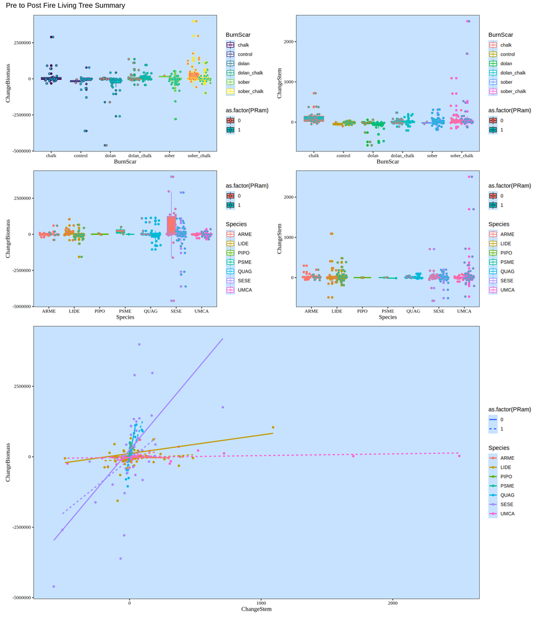

```r
den <- demo_tree |>
    ggplot(aes(x=ChangeStem, y= ChangeBiomass, color = Species, linetype = as.factor(PRam))) +
    geom_point() +
    geom_smooth(method = "lm", se =FALSE) +
    climate_theme()

dis <- demo_tree |>
    ggplot(aes(x=BurnScar, y= ChangeBiomass, color = BurnScar, fill = as.factor(PRam))) +
    geom_boxplot() +
    geom_jitter(shape = 21,
                position = position_jitterdodge(0.8)) +
    climate_theme() +
    scale_color_viridis_d()

dis2 <- demo_tree |>
    ggplot(aes(x=BurnScar, y= ChangeStem, color = BurnScar, fill = as.factor(PRam))) +
    geom_boxplot() +
    geom_jitter(shape = 21,
                position = position_jitterdodge(0.8)) +
    climate_theme()
dis3 <- demo_tree  |>
    ggplot(aes(x=Species, y= ChangeBiomass, color = Species, fill = as.factor(PRam))) +
    geom_boxplot() +
    geom_jitter(shape = 21,
                position = position_jitterdodge(0.8)) +
    climate_theme()

dis4 <- demo_tree |>
    ggplot(aes(x=Species, y= ChangeStem, color = Species, fill = as.factor(PRam))) +
    geom_boxplot() +
    geom_jitter(shape = 21,
                position = position_jitterdodge(0.8)) +
    climate_theme()


(dis + dis2) / (dis3 + dis4) / den +
  plot_annotation(title = "Pre to Post Fire Living Tree Summary") +
plot_layout(heights = c(1, 1, 2))
```

### CWD Biomass changes

```r
cwd_fire <- read_me("./clean/cwd_mass_change_fire.csv")

burn_cwd_change <- function(burn, time1) {
  df <- cwd_fire |>
    filter(BurnScar == burn) |>
    mutate(Time = case_when(
      SampleYear <= time1  ~ "Pre",
      SampleYear >= time1 ~ "Post",
      TRUE ~ "NA"))
  df_mod1 <- df |>
    filter(Time %in% c("Pre","Post")) |>
    group_by(Plot, BurnScar, Time) |>
    summarise(
      Biomass = sum(PlotCwdMass, na.rm = TRUE)) |>
    pivot_wider(names_from="Time", values_from="Biomass",names_expand = TRUE)
  df_mod2 <- df_mod1 |>
    filter(!is.na(Pre) & !is.na(Post))
  df_mod3 <- df_mod2 |>
    mutate(ChangeBiomass = Post - Pre)
  return(df_mod3)
}

sites_cwd <- tibble(
  burn  = c("dolan", "sober",  "control", "dolan_chalk", "sober_chalk"),
  time1 = c(2020, 2016, 2016, 2009, 2009)
)

cwd_demo <- pmap_df(sites_cwd, burn_cwd_change)

post_fire_cwd_summary <- cwd_demo |>
  group_by(BurnScar) |>
  summarize( n = n(),
            MeanBiomassChange = mean(ChangeBiomass, na.rm=TRUE),
            MedianBiomassChange = median(ChangeBiomass, na.rm = TRUE),
            SdBiomassChange = sd(ChangeBiomass, na.rm=TRUE),
            MinBiomassChange = min(ChangeBiomass, na.rm=TRUE),
            MaxBiomassChange = max(ChangeBiomass, na.rm=TRUE)
) |>
  rename(`Burn Scar` = 1,
          `Mean Change in Cwd Biomass` = 3,
     `Median Change in Cwd Biomass` = 4,
      `SD Change in Cwd Biomass` = 5,
     `Min Change in Cwd Biomass` = 6,
     `Max Change in Cwd Biomass` = 7)

kable(post_fire_cwd_summary)
```

| Burn Scar | n | Mean Change in Cwd Biomass | Median Change in Cwd Biomass | SD Change in Cwd Biomass | Min Change in Cwd Biomass | Max Change in Cwd Biomass |
| --- | --- | --- | --- | --- | --- | --- |
| control | 11 | 23.65021 | 9.150373 | 38.77964 | -18.95030 | 115.24793 |
| dolan | 9 | -118.27532 | -109.186383 | 78.88403 | -231.61048 | -11.04779 |
| dolan_chalk | 15 | 91.93832 | 35.620715 | 203.67198 | -31.02031 | 808.97318 |
| sober | 10 | -104.15310 | 15.717628 | 304.40390 | -774.53990 | 194.66030 |
| sober_chalk | 25 | 108.97664 | 76.214860 | 176.79068 | -85.43805 | 797.67679 |

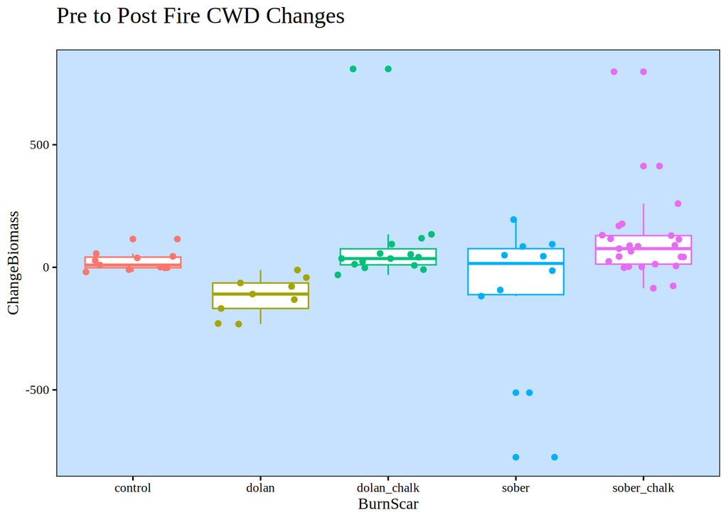

```r
cwd_uni <- cwd_demo |>
    ggplot(aes(x=BurnScar, y= ChangeBiomass, color = BurnScar)) +
    geom_boxplot(show.legend = FALSE) +
    geom_jitter(show.legend = FALSE) +
    climate_theme() +
    labs(title= "Pre to Post Fire CWD Changes")

print(cwd_uni)
```

```r
# anova testing
anov <- aov(ChangeBiomass ~ BurnScar, data = cwd_demo)
print(summary(anov))
```

```
            Df  Sum Sq Mean Sq F value  Pr(>F)
BurnScar     4  591407  147852    4.31 0.00373 **
Residuals   65 2229646   34302
---
Signif. codes:  0 '***' 0.001 '**' 0.01 '*' 0.05 '.' 0.1 ' ' 1
```

```r
print(TukeyHSD(anov))
```

```
  Tukey multiple comparisons of means
    95% family-wise confidence level

Fit: aov(formula = ChangeBiomass ~ BurnScar, data = cwd_demo)

$BurnScar
                              diff         lwr       upr     p adj
dolan-control           -141.92553 -375.496653  91.64559 0.4381818
dolan_chalk-control       68.28811 -137.996316 274.57254 0.8846829
sober-control           -127.80331 -354.860388  99.25377 0.5158436
sober_chalk-control       85.32643 -102.694691 273.34756 0.7083060
dolan_chalk-dolan        210.21364   -8.895488 429.32278 0.0661291
sober-dolan               14.12222 -224.646417 252.89087 0.9998253
sober_chalk-dolan        227.25197   25.243328 429.26061 0.0197825
sober-dolan_chalk       -196.09142 -408.242925  16.06009 0.0834421
sober_chalk-dolan_chalk   17.03832 -152.682881 186.75953 0.9985863
sober_chalk-sober        213.12974   18.689676 407.56981 0.0247122
```

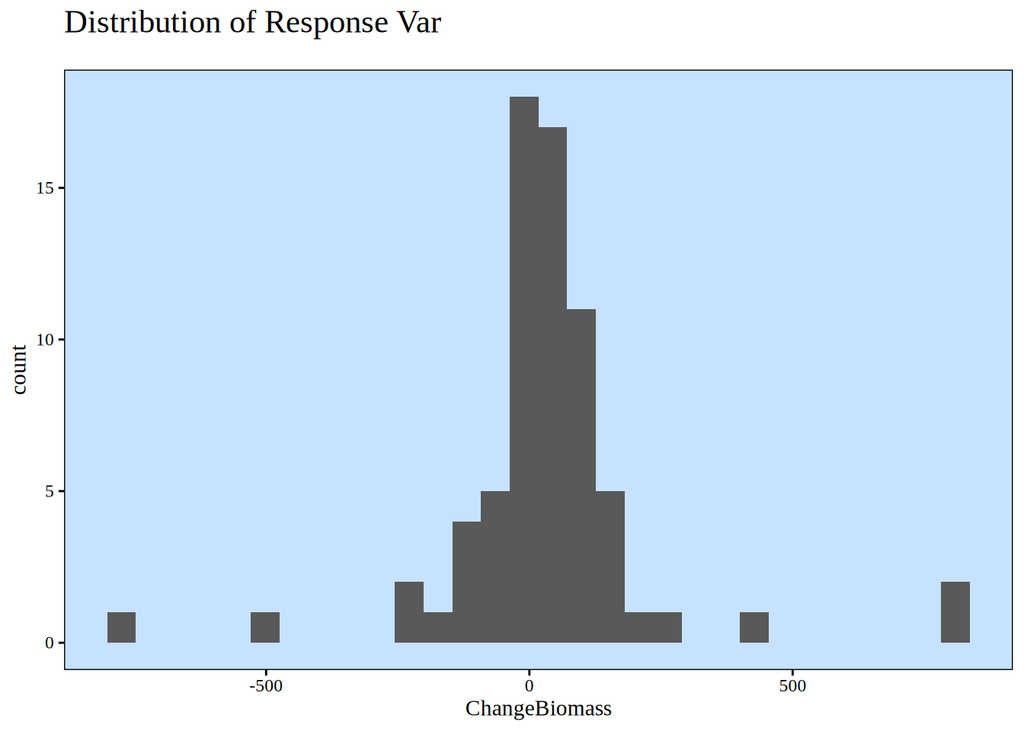

```r
norm <- cwd_demo |>
  ggplot(aes(x=ChangeBiomass)) +
  geom_histogram() +
  climate_theme() +
  labs(title = "Distribution of Response Var")
print(norm)
```

## Underlying drivers of biomass and stem density changes

### Mixed effects models

– Multiple regression with mixed effects models iterated across species  
- Attempt to understand drivers of biomass changes. Is disease and fire interacting to reduce biomass? Is it even across species.  
- Improvements: Run multiple models per species with different explanatory variables, take weighted AIC and weighted effects.  
**Questions I hope to answer**  
Which features, topographic or epidemiological, are driving biomass changes in Redwood forests?  
Is there a linear relationship between the fixed explanatory variables and biomass?

– P-values for fixed variables below the 0.05 threshold will allow us to reject our null hypothesis and indicate a linear relationship between a fixed explanatory variable and biomass.

#### Plot biomass changes

- Scaling values standardizes units? Worth doing?

```r
biomass <-  read_me("./clean/livebiomass_mixedmodel.csv")

species_df <- unique(biomass$Species)

big_biomass_model <- function(species){
  df1 <- biomass |>
    filter(Species == {{species}}) |>
    mutate(across(c(PlotCwdMass, HostCwdMass, DeadHostBiomass,
                  Elevation, Slope,LiveBiomass), scale))
  tryCatch({
    m1 <- lmer(LiveBiomass ~ PlotCwdMass + HostCwdMass + DeadHostBiomass + Elevation + Slope + Fire + PRam +
                    (1|SampleYear) + (1|Plot),
                    data=df1
                     )
    summary <- summary(m1)
    df_summary <- as.data.frame(summary$coefficients) |>
      mutate(Species = species,
              AIC = AIC(m1))
    df_summary$Term = rownames(df_summary)
    return(df_summary)
  }, error = function(e) {
    message("Error", e$message)
    return(NULL)
  })
}

interaction_model <- function(species){
  df1 <- biomass |>
    filter(Species == {{species}}) |>
    mutate(across(c(PlotCwdMass, HostCwdMass, DeadHostBiomass,
                  Elevation, Slope,LiveBiomass), scale))
  tryCatch({
    m1 <- lmer(LiveBiomass ~ PlotCwdMass * HostCwdMass * DeadHostBiomass * Elevation * Slope * Fire * PRam +
                    (1|SampleYear) + (1|Plot),
                    data=df1
                     )
    summary <- summary(m1)
    df_summary <- as.data.frame(summary$coefficients) |>
      mutate(Species = species,
              AIC = AIC(m1))
    df_summary$Term = rownames(df_summary)
    return(df_summary)
  }, error = function(e) {
    message("Error", e$message)
    return(NULL)
  })
}


#cleaning function for streamlined results
clean_me <- function(df) {
  aic_lookup <- df |> distinct(Species, AIC)
  df1 <- df |>
    rename(p = 5) |>
    mutate(Results = ifelse(
      p < 0.05,
      paste0("**", round(Estimate, 3), " (", formatC(p, format = "e", digits = 2), ")**"),
      paste0(round(Estimate, 3), " (", formatC(p, format = "e", digits = 2), ")")
    )) |>
    select(Species,Term,Results) |>
    pivot_wider(names_from="Term", values_from="Results") |>
    left_join(aic_lookup, by = "Species")
}
```

**This model uses all potential variables found to date with no interactions.**

```r
add_models <- map_df(species_df, big_biomass_model) |>
  clean_me()
kable(add_models)
```

| Species | (Intercept) | PlotCwdMass | HostCwdMass | DeadHostBiomass | Elevation | Slope | Fire | PRam | AIC |
| --- | --- | --- | --- | --- | --- | --- | --- | --- | --- |
| LIDE | 0.145 (6.24e-01) | 0.001 (9.93e-01) | **-0.268 (8.97e-04)** | **-0.233 (1.28e-04)** | -0.202 (1.08e-01) | -0.085 (5.37e-01) | **-0.497 (2.08e-02)** | 0.215 (3.33e-01) | 435.6209 |
| QUAG | -0.187 (5.34e-01) | -0.161 (2.38e-01) | -0.084 (5.54e-01) | -0.092 (6.25e-02) | 0.188 (3.17e-01) | -0.159 (3.75e-01) | -0.229 (3.19e-01) | 0.209 (3.11e-01) | 169.6953 |
| SESE | 0.278 (3.49e-01) | **-0.367 (3.46e-04)** | **0.202 (4.41e-03)** | -0.013 (8.01e-01) | **0.282 (4.28e-02)** | **-0.416 (7.42e-03)** | **-0.494 (7.44e-03)** | -0.015 (9.45e-01) | 245.3610 |
| UMCA | 0.182 (6.40e-01) | -0.147 (2.27e-01) | 0.141 (6.80e-02) | 0.017 (7.64e-01) | -0.023 (8.72e-01) | 0.093 (5.35e-01) | -0.255 (2.12e-01) | -0.143 (6.82e-01) | 290.5294 |
| ARME | 0.044 (9.20e-01) | **0.434 (2.56e-03)** | **-0.3 (2.81e-02)** | **0.347 (1.94e-03)** | -0.065 (6.83e-01) | -0.023 (8.90e-01) | -0.261 (5.06e-01) | 0.173 (5.41e-01) | 180.0132 |

**This model uses all potential variables found to date and allows for all possible interactions. Used to find interactions.**

```r
int_models <- map_df(species_df, interaction_model) |>
  clean_me()
kable(int_models)
```

| Species | (Intercept) | PlotCwdMass | HostCwdMass | DeadHostBiomass | Elevation | Slope | Fire | PRam | PlotCwdMass:HostCwdMass | PlotCwdMass:DeadHostBiomass | HostCwdMass:DeadHostBiomass | PlotCwdMass:Elevation | HostCwdMass:Elevation | DeadHostBiomass:Elevation | PlotCwdMass:Slope | HostCwdMass:Slope | DeadHostBiomass:Slope | Elevation:Slope | PlotCwdMass:Fire | HostCwdMass:Fire | DeadHostBiomass:Fire | Elevation:Fire | Slope:Fire | PlotCwdMass:PRam | HostCwdMass:PRam | DeadHostBiomass:PRam | Elevation:PRam | Slope:PRam | Fire:PRam | … |
| --- | --- | --- | --- | --- | --- | --- | --- | --- | --- | --- | --- | --- | --- | --- | --- | --- | --- | --- | --- | --- | --- | --- | --- | --- | --- | --- | --- | --- | --- | --- |
| LIDE | -1.595 (9.10e-01) | 67.234 (2.56e-01) | -114.35 (3.95e-01) | 176.4 (4.55e-01) | 36.04 (2.21e-01) | -1.956 (9.64e-01) | **43.733 (2.58e-02)** | 1.539 (9.12e-01) | 9.213 (4.25e-01) | 191.005 (2.46e-01) | -98.358 (3.33e-01) | -39.571 (1.05e-01) | 4.026 (8.66e-01) | -14.92 (5.25e-01) | 17.576 (4.02e-01) | -8.09 (2.91e-01) | 46.602 (2.22e-01) | -0.319 (8.94e-01) | 58.47 (1.92e-01) | 62.942 (4.14e-01) | -118.342 (5.82e-01) | -43.898 (3.02e-01) | 28.064 (6.48e-01) | -67.434 (2.45e-01) | 113.675 (3.98e-01) | -176.073 (4.55e-01) | -37.516 (2.10e-01) | 1.736 (9.68e-01) | **-43.927 (2.82e-02)** | … |
| QUAG | -145.019 (9.98e-01) | -99.485 (9.98e-01) | 90.426 (9.98e-01) | 50.532 (9.98e-01) | 382.93 (9.98e-01) | 48.508 (9.98e-01) | -74.293 (9.98e-01) | 140.187 (9.98e-01) | 292.053 (9.98e-01) | -256.862 (9.98e-01) | 260.951 (9.98e-01) | 383.814 (9.98e-01) | 10.195 (9.91e-01) | -6.601 (9.09e-01) | 6.664 (9.89e-01) | 1.256 (9.98e-01) | -22.438 (9.88e-01) | -6.361 (9.97e-01) | 1.455 (6.43e-01) | -1.601 (6.77e-01) | 10.909 (9.88e-01) | 13.732 (8.71e-01) | -6.251 (9.93e-01) | 94.591 (9.98e-01) | -85.541 (9.98e-01) | -60.874 (9.98e-01) | -387.086 (9.98e-01) | -45.682 (9.98e-01) | 80.119 (9.98e-01) | … |
| SESE | -1379.897 (9.46e-01) | -1760.552 (9.89e-01) | -1967.136 (8.42e-01) | 1098.514 (9.73e-01) | 1070.39 (8.19e-01) | 396.903 (9.63e-01) | 1307.512 (9.51e-01) | 1200.884 (9.37e-01) | -25.817 (9.56e-01) | -239.6 (7.58e-01) | -247.262 (6.56e-01) | 741.507 (9.73e-01) | -153.283 (9.72e-01) | 566.214 (9.45e-01) | 1220.846 (9.86e-01) | -545.255 (9.89e-01) | 500.561 (7.25e-01) | -139.698 (9.89e-01) | 1663.928 (9.90e-01) | 1917.153 (8.53e-01) | -1189.622 (9.75e-01) | -1117.318 (7.87e-01) | -401.469 (9.62e-01) | 1184.39 (9.89e-01) | 2355.121 (9.23e-01) | -1187.113 (9.71e-01) | -843.938 (7.87e-01) | 5.145 (8.87e-01) | -1128.783 (9.44e-01) | … |
| UMCA | 11.325 (7.32e-01) | -9.682 (6.70e-01) | 3.5 (5.81e-01) | 0.457 (8.95e-01) | 0.376 (9.77e-01) | 18.007 (7.47e-01) | -13.565 (7.70e-01) | -11.682 (7.24e-01) | 0.055 (9.55e-01) | 1.135 (6.20e-01) | 0.157 (8.50e-01) | -13.33 (1.73e-01) | 4.124 (1.49e-01) | 1.899 (7.84e-01) | -5.792 (2.48e-01) | 2.32 (1.24e-01) | 1.663 (6.64e-01) | 2.044 (1.85e-01) | **8.275 (3.84e-02)** | -2.553 (5.78e-02) | 2.617 (1.90e-01) | 0.48 (8.93e-01) | 0.23 (9.01e-01) | 7.547 (7.37e-01) | -2.52 (6.87e-01) | 0.109 (9.74e-01) | -4.256 (7.45e-01) | -18.927 (7.35e-01) | 15.378 (7.40e-01) | … |

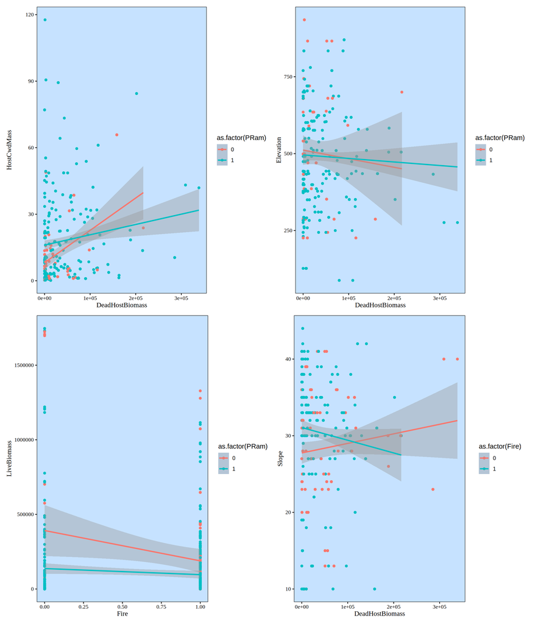

```r
int_me <- function(df,x,y,int) {
  df |>
    ggplot(aes(x={{x}},y={{y}},color=as.factor({{int}}),group=as.factor({{int}}))) +
      geom_point() +
      geom_smooth(method="lm") +
      climate_theme()
}

p1 <- int_me(biomass,DeadHostBiomass, HostCwdMass, PRam)
p2 <- int_me(biomass,DeadHostBiomass, Elevation, PRam)
p3 <- int_me(biomass,Fire, LiveBiomass,PRam)
p4 <- int_me(biomass,DeadHostBiomass, Slope, Fire)


(p1 + p2) / (p3 + p4)
```

**Other interactions to graph?**

**This model uses an interaction between HostCwdMass, DeadHostBiomass, Fire and disease.**

```r
disease_model <- function(species){
  df1 <- biomass |>
    filter(Species == {{species}}) |>
    mutate(across(c(PlotCwdMass, HostCwdMass, DeadHostBiomass,
                  Elevation, Slope,LiveBiomass), scale))
  tryCatch({
    m1 <- lmer(LiveBiomass ~ PlotCwdMass + HostCwdMass * DeadHostBiomass * Fire * PRam + Elevation * Slope +
                    (1|SampleYear) + (1|Plot),
                    data=df1
                     )
    summary <- summary(m1)
    df_summary <- as.data.frame(summary$coefficients) |>
      mutate(Species = species,
              AIC = AIC(m1))
    df_summary$Term = rownames(df_summary)
    return(df_summary)
  }, error = function(e) {
    message("Error", e$message)
    return(NULL)
  })
}

disease_models <- map_df(species_df, disease_model) |>
  clean_me()
kable(disease_models)
```

| Species | (Intercept) | PlotCwdMass | HostCwdMass | DeadHostBiomass | Fire | PRam | Elevation | Slope | HostCwdMass:DeadHostBiomass | HostCwdMass:Fire | DeadHostBiomass:Fire | HostCwdMass:PRam | DeadHostBiomass:PRam | Fire:PRam | Elevation:Slope | HostCwdMass:DeadHostBiomass:Fire | HostCwdMass:DeadHostBiomass:PRam | HostCwdMass:Fire:PRam | DeadHostBiomass:Fire:PRam | HostCwdMass:DeadHostBiomass:Fire:PRam | AIC |
| --- | --- | --- | --- | --- | --- | --- | --- | --- | --- | --- | --- | --- | --- | --- | --- | --- | --- | --- | --- | --- | --- |
| LIDE | -0.016 (9.70e-01) | -0.015 (9.02e-01) | 0.278 (5.81e-01) | -0.703 (4.65e-01) | 0.162 (7.45e-01) | 0.175 (6.60e-01) | -0.205 (1.17e-01) | -0.09 (5.39e-01) | -1.674 (1.07e-01) | -0.478 (3.96e-01) | 0.167 (8.65e-01) | -0.582 (2.71e-01) | 0.491 (6.10e-01) | -0.407 (4.07e-01) | 0.051 (7.12e-01) | 1.663 (1.12e-01) | 1.865 (7.43e-02) | 0.629 (2.85e-01) | -0.204 (8.36e-01) | **-2.153 (4.12e-02)** | 425.6804 |
| QUAG | 0.21 (6.19e-01) | -0.139 (1.39e-01) | 0.115 (7.90e-01) | 0.345 (5.36e-01) | **-1.594 (8.61e-07)** | -0.058 (8.84e-01) | **0.408 (2.58e-02)** | -0.173 (3.15e-01) | **1.58 (4.71e-02)** | **-0.473 (6.62e-08)** | **-0.555 (2.12e-10)** | 0.054 (8.98e-01) | -0.341 (5.41e-01) | **1.098 (1.06e-04)** | -0.255 (2.48e-01) | **-0.442 (1.77e-05)** | **-1.629 (4.09e-02)** | NA | NA | NA | 137.2074 |
| SESE | 0.553 (2.30e-01) | **-0.452 (5.05e-05)** | 1.131 (5.63e-02) | -0.031 (9.64e-01) | -0.509 (3.92e-01) | -0.207 (6.13e-01) | 0.214 (1.43e-01) | **-0.475 (6.82e-03)** | -1.26 (2.01e-01) | -0.977 (1.51e-01) | 0.154 (8.30e-01) | -0.909 (1.40e-01) | -0.514 (4.86e-01) | -0.171 (7.65e-01) | -0.239 (1.29e-01) | 1.213 (2.23e-01) | 1.486 (1.29e-01) | 0.947 (1.77e-01) | 0.356 (6.34e-01) | -1.439 (1.46e-01) | 261.9730 |
| UMCA | 0.627 (5.33e-01) | -0.123 (3.28e-01) | -0.463 (7.78e-01) | 1.109 (2.06e-01) | -0.506 (6.66e-01) | -0.573 (5.57e-01) | -0.085 (5.78e-01) | 0.138 (3.68e-01) | -0.765 (7.84e-01) | -0.027 (8.38e-01) | -0.005 (9.71e-01) | 0.618 (7.06e-01) | -1.088 (2.14e-01) | 0.238 (8.39e-01) | 0.184 (2.65e-01) | 0.146 (3.91e-01) | 0.726 (7.95e-01) | NA | NA | NA | 306.6452 |
| ARME | 0.467 (8.02e-01) | **0.422 (2.75e-02)** | -0.818 (5.41e-01) | 1.281 (6.12e-01) | -0.705 (7.07e-01) | -0.752 (6.63e-01) | -0.004 (9.85e-01) | -0.079 (6.93e-01) | -1.108 (3.92e-01) | 0.59 (6.61e-01) | -0.746 (7.67e-01) | 0.548 (7.28e-01) | -0.674 (7.93e-01) | 1.032 (5.61e-01) | 0.074 (6.48e-01) | 0.832 (5.23e-01) | 1.408 (3.01e-01) | -0.668 (6.75e-01) | 0.19 (9.42e-01) | -1.137 (4.10e-01) | 194.7337 |

**How do the three models compare in AIC?**

```r
model_comp <- bind_rows(
  add_models |> mutate(Model = "Simple Model"),
  int_models |> mutate(Model = "Full Interaction Model"),
  disease_models |> mutate(Model = "Disease/Fire Interaction Model")
) |>
  select(Model, Species, AIC) |>
  pivot_wider(names_from = Species, values_from = AIC) |>
  gt()

model_comp
```

| Model | LIDE | QUAG | SESE | UMCA | ARME |
| --- | --- | --- | --- | --- | --- |
| Simple Model | 435.6209 | 169.69533 | 245.3610 | 290.5294 | 180.0132 |
| Full Interaction Model | 392.3976 | 68.92514 | 104.0875 | 298.0142 | NA |
| Disease/Fire Interaction Model | 425.6804 | 137.20738 | 261.9730 | 306.6452 | 194.7337 |

### Logistic regression of mortality status

– Multiple logistic regression iterated across species  
- Attempting to predict drivers of mortality given binary health status.  
- Improvements: Use mixed effects/survival analysis instead of logistic regression.  
**Questions I hope to answer**  
Which features, topographic or epidemiological, are driving mortality in Redwood forests?  
Is there a relationship between the explanatory variables and mortality?

– P-values for fixed variables below the 0.05 threshold will allow us to reject our null hypothesis and indicate a relationship between the explanatory variables and mortality.

```r
mortality <-  read_me("./clean/mortality_mixedmodel.csv")
species_mortality <- unique(mortality$Species)

mortality_model <- function(species){
  df1 <- mortality |>
    filter(Species == {{species}})
  logistic_model <- glm(Mortality ~ PlotCwdMass + HostCwdMass + Elevation + Slope + Fire + PRam,
                    data=df1, family = binomial
                     )
  summary <- summary(logistic_model)

  df_summary <- as.data.frame(summary$coefficients) |>
     mutate(Species = species)
  df_summary$Term = rownames(df_summary)
  return(df_summary)
}

mortality_results <- map_df(species_mortality, mortality_model)

mortality_results2 <- mortality_results |>
  rename(p = 4) |>
  mutate(Results = ifelse(
    p < 0.05,
    paste0("**", round(Estimate, 3), " (", formatC(p, format = "e", digits = 2), ")**"),
    paste0(round(Estimate, 3), " (", formatC(p, format = "e", digits = 2), ")")
  )) |>
  select(Species,Term,Results) |>
  pivot_wider(names_from="Term", values_from="Results") |>
  select(!`(Intercept)`)

mortality_results3 <- mortality_results2 |>
  rename(Disease = PRam,
        `Plot Cwd Mass` = 2,
        `Host Cwd Mass` = 3)

kable(mortality_results3)
```

| Species | Plot Cwd Mass | Host Cwd Mass | Elevation | Slope | Fire | Disease |
| --- | --- | --- | --- | --- | --- | --- |
| Tanoak | -0.001 (8.75e-02) | **-0.016 (2.27e-40)** | **-0.002 (3.38e-56)** | **-0.03 (9.99e-22)** | **0.677 (2.89e-38)** | -0.03 (5.04e-01) |
| Redwood | **-0.005 (4.98e-14)** | **-0.016 (1.72e-08)** | **-0.001 (4.67e-03)** | **0.021 (2.39e-04)** | **0.368 (1.43e-04)** | **-0.289 (2.06e-04)** |
| Bay laurel | **-0.006 (2.05e-05)** | 0.001 (6.58e-01) | 0 (1.13e-01) | **-0.052 (2.07e-27)** | **1.292 (2.15e-40)** | **-0.252 (2.91e-02)** |

## Tracking stems through time

### Survival Analysis

#### 1. Need to load and transform data into survival tables

- Create t and set t0 = 2006

```r
tree <- read_me("./clean/tree_table_FINAL.csv")

tree1 <- tree |>
  filter(Species %in% c("SESE", "LIDE","UMCA")) |>
  rename(Disease = p_ram.presence,
         Fire = fire_presence) |>
  filter(!is.na(Species)) |>
  mutate(t = SampleYear - 2006,
         Species = case_when(
                             Species == "SESE" ~ "Redwood",
                             Species == "LIDE" ~ "Tanoak",
                             TRUE ~ "Bay laurel")) |>
  select(BS_plot, Species, t,RametFail,Disease,Fire, DBH)
```

#### [Kaplian - Meier](https://www.emilyzabor.com/survival-analysis-in-r.html#part-4-advanced-topics)

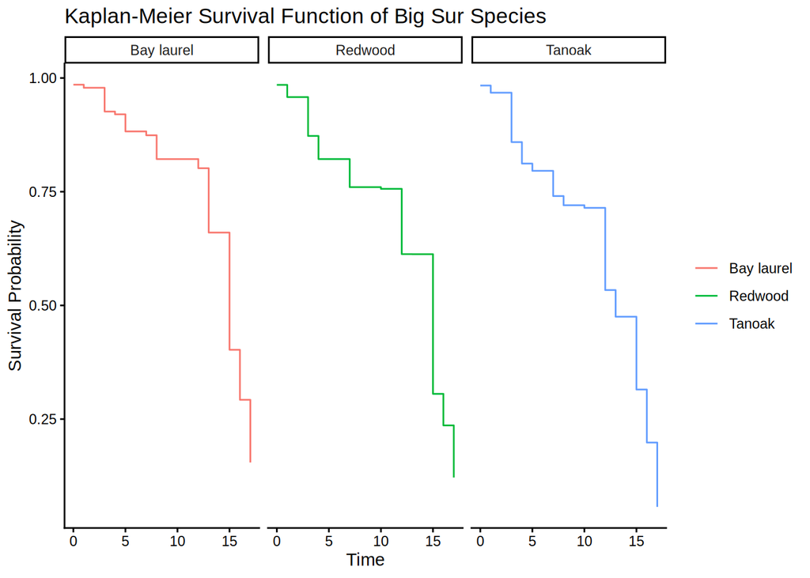

```r
s1 <- survfit2(Surv(t,RametFail) ~ Species, data=tree1)

s1 |>
  ggsurvfit() +
  facet_wrap(~strata) +
  theme_classic() +
  labs(title="Kaplan-Meier Survival Function of Big Sur Species", x="Time")
```

```r
#export_image(p1, "surv.png")

summary(s1)
```

```
Call: survfit(formula = Surv(t, RametFail) ~ Species, data = tree1)

                Species=Bay laurel
 time n.risk n.event survival  std.err lower 95% CI upper 95% CI
    0  26193     385    0.985 0.000744        0.984        0.987
    1  22175     153    0.979 0.000919        0.977        0.980
    3  20619    1101    0.926 0.001762        0.923        0.930
    4  18390     121    0.920 0.001835        0.917        0.924
    5  17616     719    0.883 0.002232        0.878        0.887
    7  14782     143    0.874 0.002322        0.870        0.879
    8  14053     841    0.822 0.002797        0.816        0.827
   12  10813     265    0.802 0.002990        0.796        0.807
   13   9872    1742    0.660 0.003940        0.652        0.668
   15   5824    2274    0.402 0.004856        0.393        0.412
   16   3260     891    0.292 0.004724        0.283        0.302
```

[output cut: 31 more lines]

```r
survdiff(Surv(t, RametFail) ~ Species, data = tree1)
```

```
Call:
survdiff(formula = Surv(t, RametFail) ~ Species, data = tree1)

                       N Observed Expected (O-E)^2/E (O-E)^2/V
Species=Bay laurel 26193     9209    12087   685.475  1249.773
Species=Redwood    20836     8527     8479     0.276     0.442
Species=Tanoak     39700    21158    18328   437.004  1044.174

 Chisq= 1416  on 2 degrees of freedom, p= <2e-16
```

### CWD Decomposition

– Influence of species,disease,fire on decomposition rate of CWD.  
– Linearized exponential decay model iterated across the species.  
– Aim to estimate values of k and compare between plot conditions.  
**Questions I hope to answer**  
How do fire, disease and species impact decomposition rates?  
Is there a linear relationship between change in mass and time?

– This piggy backs off earlier research conducted by Dr.Cobb. I am utilizing a known equation for [leaf litter decay](https://cdnsciencepub.com/doi/10.1139/x06-012). Results are simple linear regression, just a lot of build up.  
– Improvements: Split the dataset into burned/unburned, run individual models for each

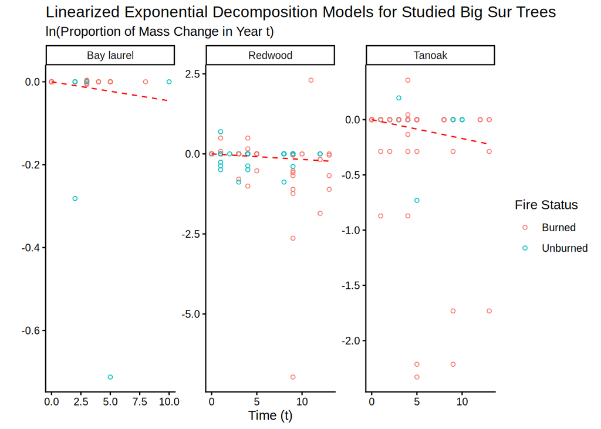

```r
cwd_decay <- read_me("./clean/cwd_decay.csv")
expo_decay <- function(species){
  df <- cwd_decay |>
    filter(Species == species)
  model <- nls(Y ~ -k*t, data=df, start=list(k=0.7))
  df$PredictedY <- predict(model)
  summary <- summary(model)

  return(df)
}
# apply model function to all species
species_vec <- unique(cwd_decay$Species)
expo_results <- map_df(species_vec, expo_decay)
# need to prepare for visuals
expo_results2 <- expo_results |>
  mutate(Fire = as.factor(Fire)) |>
  drop_na() |>
  mutate(Burn = ifelse(Fire == 0, "Unburned", "Burned"))


expo_results2 |>
  ggplot(aes(x=t,y=Y, color=Burn)) +
  geom_point(shape=1, size=1.3) +
  geom_line(aes(x=t,y=PredictedY), color="red", linetype="dashed") +
  facet_wrap(~Species,scales = "free") +
  labs(title="Linearized Exponential Decomposition Models for Studied Big Sur Trees", x="Time (t)", y="", subtitle="ln(Proportion of Mass Change in Year t)",
  color="Fire Status") +
  theme_classic()
```